# Marketing report part 1

Authors

Norah Jones

Bill Gates

Luis Francisco Gomez

Published

October 19, 2024

# 1 Describing data

## 1.2 Import data

```r
# Import the data from the sweep package
bike_sales <- bike_sales
```

## 1.3 Inspect data

Use the available functions from base R or the `tidyverse` to inspect the data

```r
# You can use str from base R
# or glimpse from the tidyverse
## If you use glimpse remember to load the
## the library in the first code chunk: library(tidyverse)
### For example glimpse(bike_sales)
bike_sales |>
  glimpse()
```

```
Rows: 15,644
Columns: 17
$ order.date         <date> 2011-01-07, 2011-01-07, 2011-01-10, 2011-01-10, 20…
$ order.id           <dbl> 1, 1, 2, 2, 3, 3, 3, 3, 3, 4, 5, 5, 5, 5, 6, 6, 6, …
$ order.line         <int> 1, 2, 1, 2, 1, 2, 3, 4, 5, 1, 1, 2, 3, 4, 1, 2, 3, …
$ quantity           <dbl> 1, 1, 1, 1, 1, 1, 1, 1, 1, 1, 1, 8, 1, 1, 1, 1, 1, …
$ price              <dbl> 6070, 5970, 2770, 5970, 10660, 3200, 12790, 5330, 1…
$ price.ext          <dbl> 6070, 5970, 2770, 5970, 10660, 3200, 12790, 5330, 1…
$ customer.id        <dbl> 2, 2, 10, 10, 6, 6, 6, 6, 6, 22, 8, 8, 8, 8, 16, 16…
$ bikeshop.name      <chr> "Ithaca Mountain Climbers", "Ithaca Mountain Climbe…
$ bikeshop.city      <chr> "Ithaca", "Ithaca", "Kansas City", "Kansas City", "…
$ bikeshop.state     <chr> "NY", "NY", "KS", "KS", "KY", "KY", "KY", "KY", "KY…
$ latitude           <dbl> 42.44396, 42.44396, 39.11405, 39.11405, 38.25267, 3…
$ longitude          <dbl> -76.50188, -76.50188, -94.62746, -94.62746, -85.758…
$ product.id         <dbl> 48, 52, 76, 52, 2, 50, 1, 4, 34, 26, 96, 66, 35, 72…
$ model              <chr> "Jekyll Carbon 2", "Trigger Carbon 2", "Beast of th…
$ category.primary   <chr> "Mountain", "Mountain", "Mountain", "Mountain", "Ro…
$ category.secondary <chr> "Over Mountain", "Over Mountain", "Trail", "Over Mo…
$ frame              <chr> "Carbon", "Carbon", "Aluminum", "Carbon", "Carbon",…
```

## 1.4 Summarize data

### 1.4.1 Summary statistics

In this section calculate some summary statistics using base R or the `skimr` package

```r
# You can use summary from base R
# or skim from the skimr package
## If you use skim remember to load the
## the library in the first code chunk: library(skimr)
### Try the 2 options: skim(bike_sales) or summary(bike_sales)
### and select the one you prefer
bike_sales |>
  skim()
```

Data summary

| Name | bike_sales |
| --- | --- |
| Number of rows | 15644 |
| Number of columns | 17 |
| _______________________ |  |
| Column type frequency: |  |
| character | 7 |
| Date | 1 |
| numeric | 9 |
| ________________________ |  |
| Group variables | None |

**Variable type: character**

| skim_variable | n_missing | complete_rate | min | max | empty | n_unique | whitespace |
| --- | --- | --- | --- | --- | --- | --- | --- |
| bikeshop.name | 0 | 1 | 11 | 28 | 0 | 30 | 0 |
| bikeshop.city | 0 | 1 | 5 | 13 | 0 | 30 | 0 |
| bikeshop.state | 0 | 1 | 2 | 2 | 0 | 21 | 0 |
| model | 0 | 1 | 6 | 31 | 0 | 97 | 0 |
| category.primary | 0 | 1 | 4 | 8 | 0 | 2 | 0 |
| category.secondary | 0 | 1 | 5 | 18 | 0 | 9 | 0 |
| frame | 0 | 1 | 6 | 8 | 0 | 2 | 0 |

**Variable type: Date**

| skim_variable | n_missing | complete_rate | min | max | median | n_unique |
| --- | --- | --- | --- | --- | --- | --- |
| order.date | 0 | 1 | 2011-01-07 | 2015-12-25 | 2013-08-25 | 962 |

**Variable type: numeric**

| skim_variable | n_missing | complete_rate | mean | sd | p0 | p25 | p50 | p75 | p100 | hist |
| --- | --- | --- | --- | --- | --- | --- | --- | --- | --- | --- |
| order.id | 0 | 1 | 997.95 | 569.69 | 1.00 | 520.00 | 985.50 | 1490.00 | 2.000e+03 | ▇▇▇▇▇ |
| order.line | 0 | 1 | 8.47 | 6.82 | 1.00 | 3.00 | 7.00 | 13.00 | 3.000e+01 | ▇▅▂▁▁ |
| quantity | 0 | 1 | 8.57 | 52.36 | 1.00 | 1.00 | 1.00 | 1.00 | 1.000e+03 | ▇▁▁▁▁ |
| price | 0 | 1 | 3521.11 | 2667.19 | 415.00 | 1840.00 | 2700.00 | 4260.00 | 1.279e+04 | ▇▅▁▁▁ |
| price.ext | 0 | 1 | 30169.88 | 229046.25 | 415.00 | 1950.00 | 3200.00 | 7000.00 | 1.066e+07 | ▇▁▁▁▁ |
| customer.id | 0 | 1 | 13.46 | 7.72 | 1.00 | 8.00 | 10.00 | 19.00 | 3.000e+01 | ▃▇▅▃▃ |
| latitude | 0 | 1 | 37.94 | 4.59 | 25.76 | 35.47 | 39.11 | 40.44 | 4.761e+01 | ▂▂▃▇▁ |
| longitude | 0 | 1 | -95.05 | 13.42 | -122.68 | -104.99 | -94.63 | -83.74 | -7.141e+01 | ▂▅▇▅▅ |
| product.id | 0 | 1 | 49.48 | 28.23 | 1.00 | 25.00 | 48.00 | 75.00 | 9.700e+01 | ▇▇▇▇▇ |

### 1.4.2 Counting

Remember that you want to support the Research and Development (R & D) division in identifying potential new products

You can use the `count` function from the `tidyverse` and the variables `category.secondary` and `frame` to identify [product gaps](https://en.wikipedia.org/wiki/Gap_analysis). In that way you can identify possible new models that are not yet offered by the corporation but that can potentially generate an important revenue:

- First, check the specific bicycle categories: `bike_sales |> count(category.secondary)`

```r
bike_sales |>
  count(category.secondary) |>
  datatable()
```

|  | category.secondary | n |
| --- | --- | --- |
| 1 | Cross Country Race | 2852 |
| 2 | Cyclocross | 668 |
| 3 | Elite Road | 3472 |
| 4 | Endurance Road | 2586 |
| 5 | Fat Bike | 294 |
| 6 | Over Mountain | 1169 |
| 7 | Sport | 1716 |
| 8 | Trail | 2020 |
| 9 | Triathalon | 867 |

- Second, check the bicycle frame materials: `bike_sales |> count(frame)`

```r
bike_sales |>
  count(frame) |>
  datatable()
```

|  | frame | n |
| --- | --- | --- |
| 1 | Aluminum | 7340 |
| 2 | Carbon | 8304 |

- Third, you can calculate the possible combinations (Hint: There are $9 \times 2 = 18$ possible combinations)

```r
bike_sales |>
  count(category.secondary, frame) |>
  datatable()
```

|  | category.secondary | frame | n |
| --- | --- | --- | --- |
| 1 | Cross Country Race | Aluminum | 998 |
| 2 | Cross Country Race | Carbon | 1854 |
| 3 | Cyclocross | Carbon | 668 |
| 4 | Elite Road | Aluminum | 1953 |
| 5 | Elite Road | Carbon | 1519 |
| 6 | Endurance Road | Aluminum | 942 |
| 7 | Endurance Road | Carbon | 1644 |
| 8 | Fat Bike | Aluminum | 294 |
| 9 | Over Mountain | Carbon | 1169 |
| 10 | Sport | Aluminum | 1716 |

[output cut: 3 more lines]

Applying the above steps, you can proceed in the following way to identify [product gaps](https://en.wikipedia.org/wiki/Gap_analysis) (Hint: Only $13$ combinations are available which means that $18 - 13 = 5$ new models can be explored):

```r
# If you have loaded the tidyverse library, library(tidyverse),
## you can learn more about this function using ?count or
## check out https://dplyr.tidyverse.org/reference/count.html
## so see the documentation online
bike_sales |>
  count(category.secondary, frame)
```

[output not shown]

Also remember that you want to support the marketing team in the creation of a marketing segmentation clustering model. Therefore the first step is to know the bicycle shops and the number of transactions. You can proceed in the following way as a first step:

```r
# Explore the argument sort in the count function
## You can check the documentation using ?count or
## checking it online
### https://dplyr.tidyverse.org/reference/count.html
bike_sales |>
  count(bikeshop.name)
```

[output not shown]

## 1.5 Data visualization

### 1.5.1 Histograms

Check the distribution of the variables `quantity` and `price` to understand its behavior using the function `hist` from base R or the `tidyverse` through the package `ggplot2`

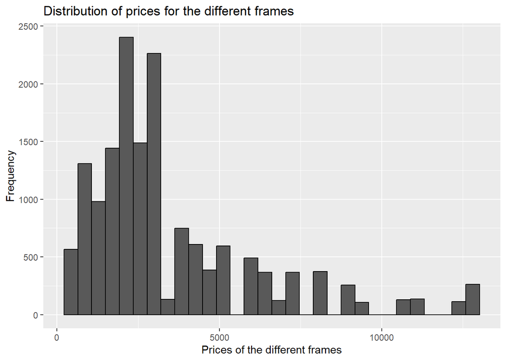

```r
# If you use base R check out the hist documentation
## ?hist
# If you use the tidyverse check out the geom_histogram
# documentation
## ?geom_histogram
### Also you can check out the online documentation in the
### case of the tidyverse
#### https://ggplot2.tidyverse.org/reference/geom_histogram.html
bike_sales |>
  ggplot() +
  geom_histogram(aes(x = price),
                 color = "black") +
  labs(x = "Prices of the different frames",
       y = "Frequency",
       title = "Distribution of prices for the different frames")
```

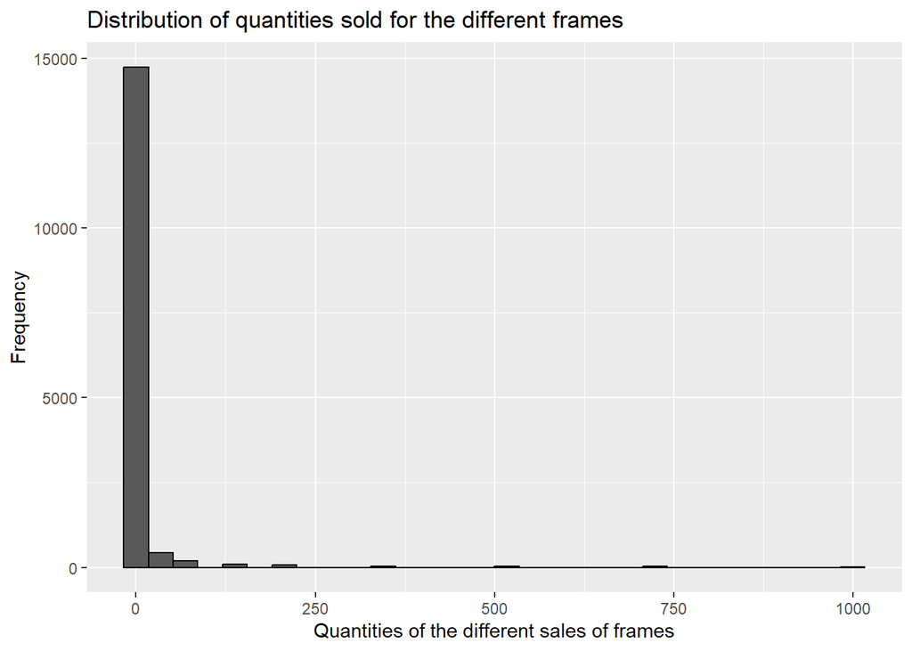

```r
# Check out the comments pointed out in the
# Quantity behavior code chunk section
bike_sales |>
  ggplot() +
  geom_histogram(aes(x = quantity),
                 color = "black") +
  labs(x = "Quantities of the different sales of frames",
       y = "Frequency",
       title = "Distribution of quantities sold for the different frames")
```

### 1.5.2 Boxplots

In this section generate 2 boxplots to explore the following items and point out the main finding in relation to these visualizations:

- Examine the revenue generated by the corporation, `price.ext`, according to the specific bicycle categories, `category.secondary`

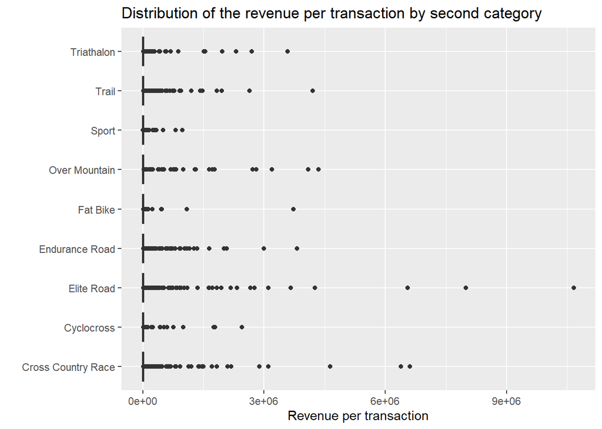

```r
bike_sales |>
  ggplot() +
  geom_boxplot(aes(x = price.ext,
                   y = category.secondary)) +
  labs(x = "Revenue per transaction",
       y = "",
       title = "Distribution of the revenue per transaction by second category")
```

- Examine the revenue generated by the corporation, `price.ext`, according to the bicycle frame material, `frame`

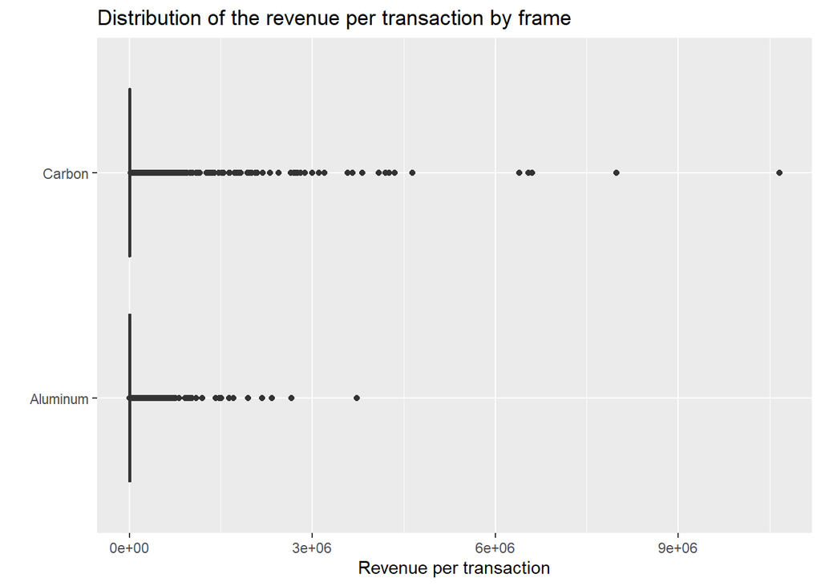

```r
bike_sales |>
  ggplot() +
  geom_boxplot(aes(x = price.ext,
                   y = frame))  +
  labs(x = "Revenue per transaction",
       y = "",
       title = "Distribution of the revenue per transaction by frame")
```

```r
# You can use the function boxplot, ?boxplot,from base R
# or the function geom_boxplot, ?geom_boxplot,from the
# tidyverse
## If you use the tidyverse check out the
## online documentation in
### https://ggplot2.tidyverse.org/reference/geom_boxplot.html
```

## 1.6 Questions answered with data

This is a miscellaneous section where the idea is to answer questions using the `bike_sales` data set. Answer the following questions using the `tidyverse` and the functions `group_by`, `summarise`, `mutate`, `fct_reorder`, `ggplot` and `geom_col`:

- What are the bike shops, `bikeshop.name`, that generate more revenue, `price.ext`, to the corporation?

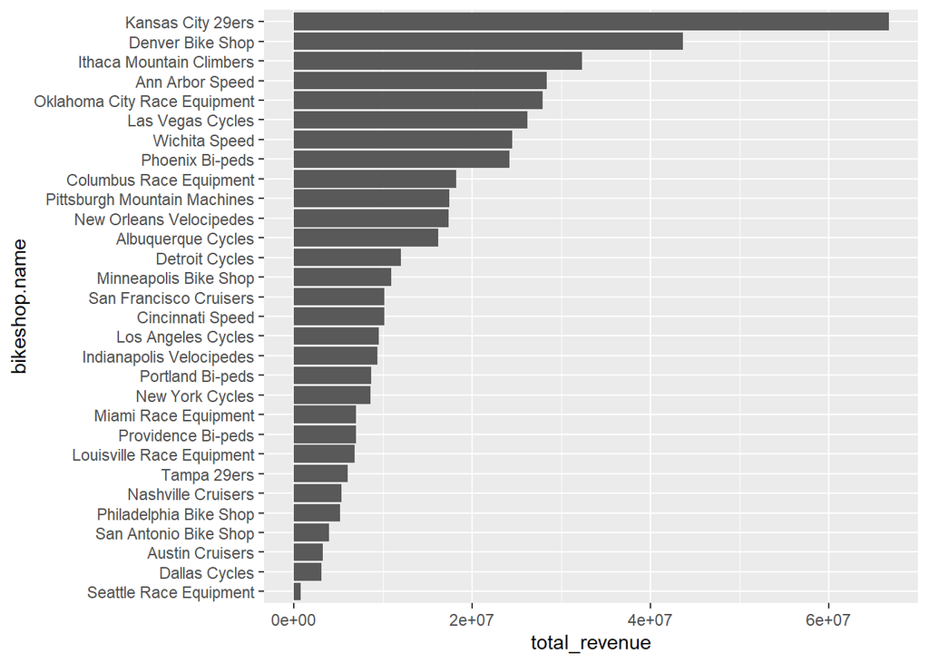

```r
revenue_by_bikeshops <- bike_sales |>
  select(bikeshop.name, price.ext) |>
  group_by(bikeshop.name) |>
  summarise(total_revenue = sum(price.ext)) |>
  mutate(bikeshop.name = fct_reorder(.f = bikeshop.name,
                                     .x = total_revenue))

revenue_by_bikeshops |>
  ggplot() +
  geom_col(aes(x = total_revenue,
               y = bikeshop.name))
```

To answer the above questions divide the process in 2 states:

- First, prepare the data
- Second, visualize the data

You can use the following example as a guidance where the variable `bikeshop.city` is used to answer what cities generate more revenue, `price.ext`:

```r
# Prepare data
bike_sales_total_revenue_by_city <- bike_sales |>
  group_by(bikeshop.city) |>
  summarise(total_revenue = sum(price.ext)) |>
  mutate(bikeshop.city = fct_reorder(.f = bikeshop.city,
                                     .x = total_revenue))

# Visualize data
bike_sales_total_revenue_by_city |>
  ggplot(aes(x = total_revenue, y = bikeshop.city)) +
  geom_col()
```